# 6 - compensadores slides

## Compensador dinâmico

Já aprendemos a projetar um regulador, que é um conjunto de ganhos que calcula a ação de controle usando os estados do sistema.

Também aprendemos a projetar um observador de estados, que é um sistema dinâmico cuja função é fornecer uma estimativa dos estados reais do sistema a partir do sinal de saída.

O compensador dinâmico é a junção destas duas ideias no mesmo sistema.

A Figura abaixo esquematiza todos os subsistemas e rotas de sinal com a estratégia adotada.

[figure not shown]

No final, nosso controlador projetado com essas abordagens é um único sistema, cujas equações de estado são: \begin{align*} \dot{\mathbf{x}}_e &= \mathbf{(A-BK-LC)}\mathbf{x}_e+\mathbf{L}y\\ u &= \mathbf{-K}\mathbf{x}_e \end{align*} onde $\mathbf{x}_e$ é a estimativa dos estados do sistema pelo observador, $\mathbf{K}$ e $\mathbf{L}$ são respectivamente os ganhos do regulador e do observador. Note que a entrada do controlador é a saída da planta. Da mesma forma, o sinal de saída do controlador é o sinal de controle $u$, que vai para a entrada da planta.

Perceba, que estas duas equações permitem realizar o controlador como um sistema entrada-saída normal, com uma função de transferência que basicamente dispensa as equações de estado, para fins de implementação. Esta função é: \begin{align*} Q(s) &= -\mathbf{K}(s\mathbf{I-A+BK+LC})^{-1}\mathbf{L} \end{align*}

Para fins de simulação, o sistema completo (planta+controlador) podem ser simulados usando um único conjunto de equações de estados: \begin{align*} \dot{\mathbf{x}} &= \mathbf{A}\mathbf{x}-\mathbf{BK}\mathbf{x_e}\\ \dot{\mathbf{x}}_e &= \mathbf{(A-BK-LC)}\mathbf{x}_e+\mathbf{LCx}\\ y&= \mathbf{Cx} \end{align*}

É possível demonstrar que os pólos de malha fechada compensado por um controlador dessa natureza são exatamente os pólos projetados pelo regulador de estados completo (isto é, considerando realimentação dos estados verdadeiros, mesmo que na prática não vá ser assim no final) e o pólos alocados para o observador.

Em outras palavras, o polinômio de malha fechada quando usamos um compensador que combina regulador+observador é simplesmente: \begin{align*} \alpha_{\text{mf}}(s) = \alpha_{\text{reg}}(s)\cdot \alpha_{\text{obs}}(s) \end{align*} onde "mf", "reg" e "obs" indicam respectivamente "malha fechada", "regulador" e "observador".

O fato do projeto dos dois sistemas não "misturar" os pólos é um fato notável, que permite que os projetos sejam feitos de forma independente. Isso é chamado de principío da separação em teoria de controle.

### Compensador com referência

Considerando a entrada $u = Nr - \mathbf{K}\mathbf{x}_e$ e um sistema com $D=0$, as equações de estado ficam:

\begin{align} \dot{\mathbf{x}} &= \mathbf{Ax}-\mathbf{BK}\mathbf{x}_e +\mathbf{B}Nr\\ \dot{\mathbf{x}}_e &= \mathbf{(A-BK-LC)}\mathbf{x}_e+\mathbf{L}y +\mathbf{B}Nr\\ y &= \mathbf{Cx} \end{align}

Para fins de simulação, é interessante blocar as matrizes para termos uma única representação global em malha fechada e podermos simular. \begin{align} \begin{bmatrix}\dot{\mathbf{x}}\\\dot{\mathbf{x}}_e\end{bmatrix} &= \begin{bmatrix} \mathbf{A} & \mathbf{-BK} \\ \mathbf{LC} & \mathbf{A-BK-LC}\end{bmatrix} \begin{bmatrix} {\mathbf{x}}\\{\mathbf{x}}_e\end{bmatrix} + \begin{bmatrix}\mathbf{B}N \\ \mathbf{B}N\end{bmatrix}r\\ y &= \begin{bmatrix}\mathbf{C} & \mathbf{0}\end{bmatrix}\begin{bmatrix} {\mathbf{x}}\\{\mathbf{x}}_e\end{bmatrix} \end{align}

Com essas matrizes também podemos calcular o valor do ganho de referência $N$ a fim de fornecer erro de regime nulo para uma entrada degrau, da mesma forma que já foi explicado, porém usando as matrizes blocadas.

[figure not shown]

```python
# Imports
import control as ct
import numpy as np
import matplotlib.pyplot as plt
```

```python
# Declaração das matrizes e do sistema
A = np.array([[0,1],[0,0]])
B = np.array([[0],[1]])
C = np.array([[1,0]])
D = np.array([[0]])
sys = ct.ss(A,B,C,D)
```

```python
# Controlabilidade
Co= ct.ctrb(A,B)
```

A matriz de controlabilidade é

$$ \mathcal{C} = \left[\begin{matrix}0 & 1.0\\1.0 & 0\end{matrix}\right] $$

O determinante é $-1.0$, logo o sistema é controlável.

```python
# Pólos do regulador:
xi = 0.707
wn = 1
p = wn*(-xi+1j*np.sqrt(1-xi**2))
pr = [p, np.conj(p)]


# Cálculo do regulador
K = ct.acker(A,B,pr)
```

$$ \mathbf{K} = \left[\begin{matrix}1.0 & 1.414\end{matrix}\right]$$

```python
# Pólos do observador:
xi = 0.5
wn = 5
p = wn*(-xi+1j*np.sqrt(1-xi**2))
po = [p, np.conj(p)]

# Cálculo do observador
L = ct.acker(A.T,C.T,po).T
```

$$ \mathbf{L} = \left[\begin{matrix}5.0\\25.0\end{matrix}\right] $$

```python
# Função de transferência do controlador:
comp = ct.ss(A-B@K-L@C, L, -K,0)
Qs = ct.tf(comp)
```

$$ Q(s) = \frac{- 40.35 s - 25.0}{1.0 s^{2} + 6.414 s + 33.07} $$

```python
# Matrizes em bloco para o sistema em malha fechada:
Amf = np.block([[A, -B@K],[L@C, A-B@K-L@C]])
Bmf = np.block([[B],[B]])
Cmf = np.block([[C, np.zeros(C.shape)]])

# Cálculo do ganho de referência:
N = 1/(Cmf @ np.linalg.inv(-Amf) @ Bmf)

# Redefinir a matriz $\mathbf{B}$ de malha fechada para introduzir o ganho $N$
Bmf = Bmf @ N
```

```python
# Define o sistema em malha fechada
sis_mf = ct.ss(Amf,Bmf,Cmf, 0)

# Simula em malha fechada
out = ct.step_response(sis_mf)
```

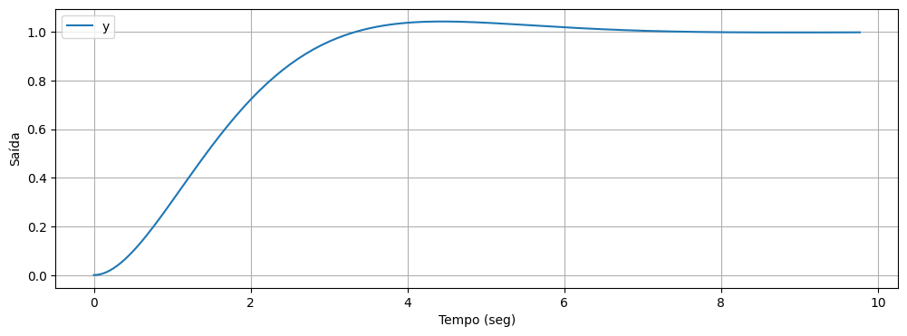

```python
# Plota:
plt.figure(figsize=(12,4))
plt.plot(out.t,out.outputs)
plt.grid()
plt.xlabel('Tempo (seg)')
plt.ylabel('Saída')
plt.legend('y')
plt.show()
```

[figure not shown]

## Controle integral

Sabemos que um integrador em malha aberta zera o erro de regime permanente quando fechamos a malha (para uma referência degrau pelo menos) e permite ao sistema rejeitar distúrbios (do tipo degrau). Portanto, a introdução de integradores na malha aberta é um aspecto desejável do projeto.

Para introduzir um integrador no espaço de estados, adicionamos um novo estado ao sistema, que representa a integral do erro à referência: \begin{align*} {e} = \int (r-y)dt \end{align*}

Supondo que $y=\mathbf{Cx}$, a equação de estado deste novo sinal é: \begin{align*} \dot{e} = r-\mathbf{Cx} \end{align*}

Essa última equação aumenta a ordem do sistema em 1. O sistema em malha aberta agora fica: \begin{align*} \dot{\mathbf{x}} &= \mathbf{Ax}+\mathbf{B}u\\ \dot{e} &= r-\mathbf{Cx} \end{align*}

Em notação matricial em blocos temos: \begin{align*} \left[\begin{array}{c}\dot{\mathbf{x}}\\ \dot{e}\end{array}\right]&= \left[\begin{array}{cc}\mathbf{A} & \mathbf{0}\\-\mathbf{C} & 0\end{array}\right]\left[\begin{array}{c}{\mathbf{x}}\\ {e}\end{array}\right]+\left[\begin{array}{c}\mathbf{B}\\ 0\end{array}\right]u+\left[\begin{array}{c}\mathbf{0}\\ 1\end{array}\right]r \end{align*}

Dizemos que o sistema está *aumentado*

O algoritmo de controle integral consiste em fazer uma realimentação completa de todos os estados agora definidos. \begin{align*} u = -\mathbf{Kx}-K_ie = -\mathbf{K}_a\mathbf{x}_a \end{align*} onde \begin{align*} \mathbf{x_a} &= \left[\begin{matrix}\mathbf{x} & e\end{matrix}\right]^T\\ \mathbf{K_a} &= \left[\begin{matrix}\mathbf{K} & K_i\end{matrix}\right]^T \end{align*}

Algoritmo de projeto:

- Construa as matrizes aumentadas: \begin{align*} \mathbf{A}_a &= \left[\begin{array}{cc}\mathbf{A} & \mathbf{0}\\-\mathbf{C} & 0\end{array}\right]\\ \mathbf{B}_a &=\left[\begin{array}{c}\mathbf{B}\\ 0\end{array}\right] \end{align*}
- Resolva o problema de regulação com $(\mathbf{A}_a, \, \mathbf{B}_a)$, para encontrar a matriz de ganhos aumentada $\mathbf{K}_a$

### Escolha dos pólos

Perceba que a introdução de um integrador aumenta a ordem do sistema e isso vai requerer a especificação de pólos adicionais. Tente alocar estes pólos em posições estratégicas para não comprometer a dominância dos pólos desejados.

### Equações de estado do compensador:

No controle integral, projetamos o observador de estados normalmente, como se o integrador não estivesse presente.

Supondo que os estados do observador são $\mathbf{z}=\hat{\mathbf{x}}$, as equações do compensador serão:

\begin{align} \dot{\mathbf{z}}&= (\mathbf{A}'-\mathbf{B}'\mathbf{K}_a-\mathbf{L}_0\mathbf{C}')\mathbf{z}+\mathbf{L}_1y+\mathbf{M}r\\ u &= \mathbf{-K}_a\mathbf{z} \end{align} As matrizes aumentadas são:

\begin{align} \mathbf{A}' &= \left[ \begin{array}{ll} \mathbf{A} & \mathbf{0}_{n\times 1}\\ \mathbf{0}_{1\times n} & 0 \end{array}\right]\\ \mathbf{B}' &= \left[\begin{array}{cc} \mathbf{B} \\ {0} \end{array}\right]\\ \mathbf{C}' &= \left[\begin{array}{cc} \mathbf{C} & {0} \end{array}\right]\\ \mathbf{L}_0 &= \left[\begin{array}{cc} \mathbf{L} \\ {0} \end{array}\right]\\ \mathbf{L}_1 &= \left[\begin{array}{rr} \mathbf{L} \\ {-1} \end{array}\right]\\ \mathbf{M} &= \left[\begin{array}{cc} \mathbf{0}_{n\times 1} \\ 1 \end{array}\right] \end{align}

É interessante observar que esse compensador requer duas entradas distintas para ser realizado: a referência e a saída da planta.

Lembre-se que do ponto de vista do controlador, a saída é o sinal de controle $u$. Portanto, a saída da planta $y$ é vista por ele como uma entrada, assim como a referência $r$.

Podemos enxergá-lo através de duas funções de transferência: uma de $Y$ para $U$ e outra de $R$ para $U$. Assim, a saída do controlador poderia ser descrita como:

\begin{align} U(s) = C_1(s)Y(s)+C_2(s)R(s) \end{align}

As funções de transferência $C_1(s)$ e $C_2(s)$ podem ser calculadas pelas matrizes usando a expressão que já estudamos.

Do ponto de vista de fluxo de sinal, o sistema controlador funciona conforme o diagrama de blocos a seguir

[figure not shown]

Esse diagrama pode ser modificado para utilizar a estrutura convencional de controle com realimentação unitária, mas nesse caso, o bloco que alimenta a referência sofre modificação (*desafio: verifique que diagrama é esse*)

### Simulação em malha fechada

Com a realimentação do sistema aumentado, as equações em malha fechada serão:

\begin{align*} \dot{\mathbf{x}} &= \mathbf{A}\mathbf{x}-\mathbf{B}\mathbf{K}_a\mathbf{z}\\ \dot{\mathbf{z}} &= (\mathbf{A'}-\mathbf{B'}\mathbf{K}_a-\mathbf{L}_0\mathbf{C}')\mathbf{z}+\mathbf{L}_1\mathbf{C}\mathbf{x}+\mathbf{M}\, r\\ y&= \mathbf{Cx} \end{align*}

Matrizes de malha fechada:

\begin{align} \mathbf{A}_{\text{mf}} &= \left[\begin{array}{cc} \mathbf{A} & -\mathbf{B}\mathbf{K}_a\\ \mathbf{L}_1\mathbf{C} & \mathbf{A}'-\mathbf{B}'\mathbf{K}_a-\mathbf{L}_0\mathbf{C}' \end{array}\right]\\ \mathbf{B}_{\text{mf}} &= \left[\begin{array}{cc} \mathbf{0}_{n\times 1} \\ \mathbf{M} \end{array}\right] = \left[\begin{array}{cc} \mathbf{0}_{2n\times 1} \\ 1 \end{array}\right]\\ \mathbf{C}_{\text{mf}} &= \left[\begin{array}{cc} \mathbf{C} & \mathbf{0}_{1\times (n+1)} \end{array}\right]\\ \mathbf{D}_{\text{mf}} &= 0 \end{align}

Perceba que a realimentação de estados é feita através do sinal $u$. O sinal $r$, de referência não deve ser usado para realimentar.

**Exemplo:**

Construa um compensador com controle integral para o sistema \begin{align} G(s) = \frac{10}{(s+1)(s+2)} \end{align} para que $\xi = 0.7$ e $\omega_n=2$.

```python
# Imports
import numpy as np
import control as ct
import sympy as sp
```

```python
# Declara o sistema
A = np.array([[-3,-2],[1,0]])
B = np.array([[1],[0]])
C = np.array([[0,10]])
D = np.array([[0]])
```

\begin{align} \dot{\mathbf{x}} &= \left[\begin{matrix}-3 & -2\\1 & 0\end{matrix}\right]\mathbf{x} + \left[\begin{matrix}1\\0\end{matrix}\right]u\\ y &= \left[\begin{matrix}0 & 10\end{matrix}\right]\mathbf{x} \end{align}

```python
# Matrizes aumentadas
Aa = np.block([[A, np.zeros([2,1])],[-C, 0]])
Ba = np.block([[B],[0]])
```

\begin{align} \mathbf{A}_a &= \left[\begin{matrix}-3.0 & -2.0 & 0\\1.0 & 0 & 0\\0 & -10.0 & 0\end{matrix}\right]\\ \mathbf{B}_a &= \left[\begin{matrix}1\\0\\0\end{matrix}\right] \end{align}

```python
# Especificações
xi = 0.7
wn = 2
# Polos de MF desejados
pr = wn*(-xi+1j*np.sqrt(1-xi**2))
```

Pólos desejados: $$ s = -1.4 \pm j 1.4283 $$

Como o projeto ficou de terceira ordem, precisamos completar com um pólo. Para não interferir na dominância, vamos alocá-lo com uma frequência natural 5 vezes maior. Assim, o pólo extra será $s=-10$.

```python
p = [pr, np.conj(pr), -5*abs(pr)]
print(p)
```

```
[(-1.4+1.42828568570857j), (-1.4-1.42828568570857j), -10.0]
```

```python
# Projeto do ganho aumentado com Ackermann
Ka = ct.acker(Aa,Ba,p)
```

\begin{align} \mathbf{K}_a = \left[\begin{matrix}9.8 & 30.0 & -4.0\end{matrix}\right] \end{align}

Para o projeto do observador, podemos usar pólos distantes em um fator de 10 dos pólos originais.

```python
po = [10*pr, 10*np.conj(pr)]
print(po)
```

```
[(-14+14.282856857085699j), (-14-14.282856857085699j)]
```

```python
# Projeto do observador
L = ct.acker(A.T, C.T, po).T
print(L)
```

```
[[32.3]
 [ 2.5]]
```

Vamos agora escrever as equações de estado do controlador.

```python
# Matrizes auxiliares:
n = 2
Al = np.block([[A,np.zeros((n,1))],[np.zeros((1,n+1))]])
Bl = Ba
Cl = np.block([C,0])
L0 = np.block([[L],[0]])
L1 = np.block([[L],[-1]])
M = np.block([[np.zeros((n,1))],[1]])
```

```python
# Matrizes do controlador
Ac = Al-Bl@Ka-L0@Cl
B1 = L1
B2 = M
Cc = -Ka
D1 = np.array([[0]])
D2 = np.array([[0]])
```

Equações do controlador: \begin{align} \dot{\mathbf{z}} &= \left[\begin{matrix}-12.8 & -355.0 & 4.0\\1.0 & -25.0 & 0\\0 & 0 & 0\end{matrix}\right] \mathbf{z} + \left[\begin{matrix}32.3\\2.5\\-1.0\end{matrix}\right] y + \left[\begin{matrix}0\\0\\1.0\end{matrix}\right] r\\ u &= \left[\begin{matrix}-9.8 & -30.0 & 4.0\end{matrix}\right] \mathbf{z} \end{align}

Funções de transferência do controlador. Primeiro, da saída do sistema $y$ para o sinal de controle $u$. Atenção para a matriz $\mathbf{B}$ utilizada em cada caso.

```python
C1 = ct.ss(Ac, B1, Cc, D1)
C1 = ct.tf(C1)
```

\begin{align} C_1(s) &= \frac{- 395.54 s^{2} - 1257.0 s - 1600.0}{1.0 s^{3} + 37.8 s^{2} + 675.0 s} \end{align}

Depois, a função entre o sinal de controle e a referência:

```python
C2 = ct.ss(Ac, B2, Cc, D2)
C2 = ct.tf(C2)
```

\begin{align} C_2(s) &= \frac{4.0 s^{2} + 112.0 s + 1600.0}{1.0 s^{3} + 37.8 s^{2} + 675.0 s} \end{align}

```python
# Pólos e zeros do controlador:
print("Pólos: {p}".format(p=C1.poles().round(2)))
print("Zeros C1: {z}".format(z = C1.zeros().round(2)))
print("Zeros C2: {z}".format(z = C2.zeros().round(2)))
```

```
Pólos: [-18.9+17.83j -18.9-17.83j   0.  +0.j  ]
Zeros C1: [-1.59+1.23j -1.59-1.23j]
Zeros C2: [-14.+14.28j -14.-14.28j]
```

Para verificar o projeto, montamos um sistema em malha fechada e simulamos uma referência degrau.

```python
# Matrizes em malha fechada:
Amf = np.block([[A  ,  -B@Ka ] , [ L1@C ,  Al-Bl@Ka-L0@Cl ] ])
Bmf = np.block([[np.zeros(B.shape)],[M]])
Cmf = np.block([C, np.zeros([1,3])])
Dmf = 0

# Sistema e simulação
sis_mf = ct.ss(Amf,Bmf,Cmf,Dmf)
resp = ct.step_response(sis_mf)
```

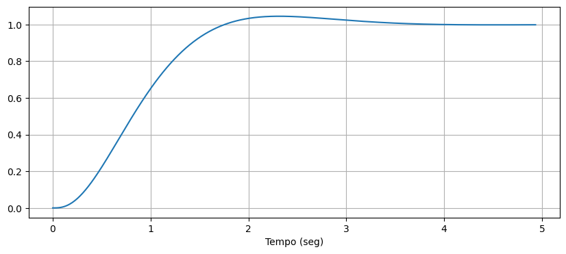

```python
# Gráficos
plt.figure(figsize=(10,4))
plt.plot(resp.t, resp.outputs)
plt.grid()
plt.xlabel('Tempo (seg)')
plt.show()
```

É sempre prudente analisar a resposta também em termos de pólos e zeros de malha fechada. Isso é especialmente útil quando a simulação parece não exibir o comportamento que foi solicitado no projeto.

```python
tabela = ct.damp(sis_mf)
sis_mf.zeros().round(2)
```

```
    Eigenvalue (pole)       Damping     Frequency
       -14    +14.28j           0.7            20
       -14    -14.28j           0.7            20
                  -10             1            10
      -1.4    +1.428j           0.7             2
      -1.4    -1.428j           0.7             2
```

```
array([-14.+14.28j, -14.-14.28j])
```

Devemos analisar este resultado buscando possíveis cancelamentos entre pólos e zeros. Observe também que a planta não possui zeros. Os zeros que surgem na malha são provenientes do próprio controlador.

*Sinal de controle:* durante o projeto é muito importante também analisar o sinal de controle que resulta da ação do compensador. Lembre-se que o sinal de controle é $u = -\mathbf{K}_a\mathbf{z}$. Para coletar e visualizar o sinal da simulação, basta introduzir uma nova saída ao sistema, com base nos ganhos aumentados.

```python
Cmf = np.block([[Cmf],[np.zeros(C.shape), -Ka]])
Dmf = np.zeros((2,1))
sis_mf = ct.ss(Amf,Bmf,Cmf,Dmf)
resp = ct.step_response(sis_mf)
```

O sistema agora tem duas saídas. Para plotar apenas o sinal de controle, usamos a segunda saída, conforme definimos acima.

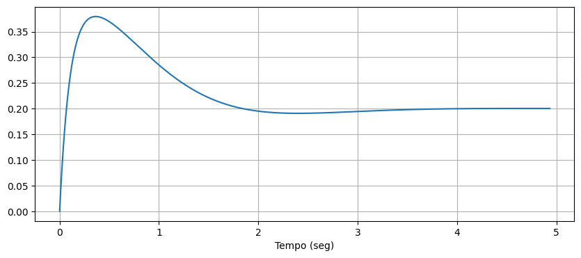

```python
plt.figure(figsize=(10,4))
plt.plot(resp.t, resp.y[1].T)
plt.grid()
plt.xlabel('Tempo (seg)')
plt.show()
```

Como pode ser visto o sinal possui baixa amplitude e possui um valor de regime constante para manter o sistema funcionando de acordo com o comando de referência.

Para verificar a robustez da ação integral, podemos introduzir um sinal de perturbação em malha fechada e conferir se o sistema volta para o ponto de operação após a perturbação.

Uma perturbação pode ser introduzida na forma de um pequeno sinal de entrada nos estados internos do próprio sistema. Neste caso, vamos introduzir este sinal no primeiro estado do sistema. Para isso acrescentamos uma coluna à matriz $\mathbf{B}$.

```python
Bmf = np.block([[np.zeros(B.shape)],[M]])
Bmf = np.block([Bmf, np.zeros(Bmf.shape)])
Bmf[0,1] = 1
Dmf = np.zeros((2,2))

# Redefine o sistema
sis_mf = ct.ss(Amf,Bmf,Cmf,Dmf)
```

Para simular a perturbação precisamos primeiro definir o sinal de perturbação. Distúrbios podem ser simulados como um degrau atrasado, que se inicia após o sistema ter entrado em regime. Neste caso, precisamos fazer um controle mais rigoroso de tempo

```python
tempo = np.linspace(0,10,1000)
d = 0.3*np.float16(tempo>=5)
r = 1.0*np.float16(tempo>=0)
```

```python
# Matriz de sinais de entrada para simulação. Uma entrada em cada linha
u = np.block([[r],[d]])
```

Simulação. Note que para usar sinais diferentes do degrau untário padrão, precisamos usar outro comando de simulação.

```python
resp = ct.input_output_response(sis_mf,tempo,u)
```

Plotagem dos sinais de saída.

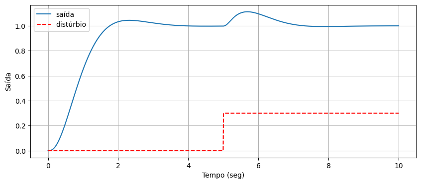

```python
plt.figure(figsize=(10,4))
plt.plot(tempo, resp.y[0])
plt.plot(tempo, d,'r--')
plt.grid()
plt.xlabel('Tempo (seg)')
plt.ylabel('Saída')
plt.legend(['saída','distúrbio'])
plt.show()
```

Note que a perturbação tenta tirar o sistema do ponto de operação, mas o controlador impede, fazendo o retornar ao nominal **apesar do fato da perturbação continuar ativa**.